# IA no judiciário e dados abertos

Como estruturar dados judiciais, acessá-los e abri-los para a pesquisa

Julio Trecenti · Insper, LabDados FGV Direito SP, CEOE/Unifesp

30/10/2026

## Estruturar dados ficou fácil, mas acesso e legitimidade seguem em aberto

1

**Dá para fazer?**

Estruturar texto judicial ficou fácil e barato.

2

**Como acessamos?**

Os grandes repositórios têm portas pagas e estreitas.

3

**Podemos fazer?**

Os dados são públicos, mas têm informação pessoal.

Temos a chance de criar bases estruturadas do Judiciário em escala nunca vista. Talvez seja o projeto mais importante da área agora.

## Estruturar textos judiciais ficou fácil

## Uma sentença pode virar uma linha de tabela

“… apreendidos 03 pinos de cocaína e 65 porções de maconha em poder do réu … Ante o exposto, julgo procedente a denúncia para condenar o acusado à pena de 5 anos e 10 meses de reclusão, em regime inicial fechado …”

Trecho ilustrativo de sentença criminal

| variável | valor |
| --- | --- |
| `cocaina_pinos` | 3 |
| `maconha_porcoes` | 65 |
| `decisao` | condenado |
| `pena_anos` | 5,83 |

O Judiciário guarda quase tudo em **texto livre**. A variável que responde à pergunta de pesquisa quase nunca está nos metadados.

## Saídas estruturadas reduziram a extração de dados a poucas linhas de código

**Anotação manual**

Padrão-ouro, mas cara e difícil de padronizar.

**Expressões regulares**

Funcionam no caso que você viu e quebram no próximo.

**Machine learning**

Generaliza, mas exige uma base anotada antes.

**LLM com saída estruturada**

Pré-treinado. Você descreve as variáveis e recebe a tabela.

```python
class Sentenca(BaseModel):
    decisao: Literal["condenado", "absolvido", "arquivado"]
    qtd_cocaina: float
    pena_anos: float
```

O esquema vira uma gramática, e o modelo só pode gerar o que cabe nela. Em Python, dataframeit; em R, `ellmer`.

## O Jev responde perguntas fechadas sem gerar texto

O **Jev** (TypeSafe AI, setembro de 2026) é um modelo “System One”:

- recebe o texto e **perguntas tipadas**;
- devolve só as opções definidas;
- dá uma **probabilidade** para cada resposta.

Modelo fechado, com acesso por API.

Choice Qual foi o resultado? procedente · 0,97

Score Qual a gravidade do dano? média · 0,74

Noul A sentença decide com base na inversão do ônus? sim · 0,52

Respostas ilustrativas

12 variáveis fechadas em 120 sentenças cíveis, com gabarito por consenso de modelos fortes e adjudicação cega, sem juristas. [LabDados, set/2026](https://lab-dados.github.io/jev-anotacao-sentencas/).

## Já existem alternativas abertas ao Jev que rodam na sua própria máquina

|  | O que é | Abertura |
| --- | --- | --- |
| **[Kev](https://github.com/jaredpalmer/kev)** | família de modelos tipados sobre Qwen, de 0,8B a 27B, compatível com o SDK do Jev | pesos e treino abertos, Apache-2.0 |
| **[this-that-model](https://arxiv.org/abs/2609.23886)** | modelo tipado de 2 bilhões de parâmetros, cerca de 30 ms em GPU de notebook | pesos no Hugging Face, MIT |
| **poorjev** | mesma interface do Jev, com modelo de NLI local | código MIT |
| **LLMs de pesos abertos** | modelo local com saída estruturada (Outlines, Ollama, vLLM) | varia por modelo |

Modelo local significa **texto que não sai de casa**, custo marginal perto de zero e experimento reproduzível. Mas falta testar essas alternativas em português jurídico: **esse benchmark ainda está por fazer**.

## Uma oportunidade para a pesquisa empírica em Direito

## Já usamos essas ferramentas em pesquisas e em órgãos públicos

## O projeto mais importante da área é criar métodos e repositórios abertos

**Coletar**

raspagem e APIs

**Estruturar**

esquema e modelo

**Validar**

amostra humana, triagem por confiança

**Proteger**

anonimizar, publicar variáveis

**Abrir**

repositório, licença, documentação

**Métodos seguros, baratos e fáceis de usar**, para que pesquisar o Judiciário não dependa de uma equipe de engenharia.

**Repositórios estruturados abertos**, para pesquisadores e sociedade civil, sem que cada grupo refaça tudo do zero.

Só que há duas perguntas no caminho: como acessamos e se podemos usar.

## Como acessamos os dados do Judiciário?

## Por muito tempo, pesquisar o Judiciário dependia de papel e de robôs

2010

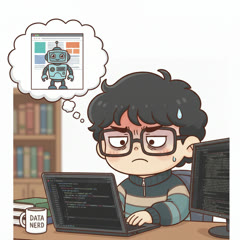

**Sem base pronta.** No estudo do CARF, aprendi a escrever robôs.

2012

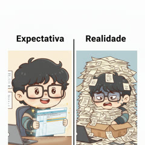

**LAI em papel.** No estudo de adoção, os dados vieram impressos.

2014

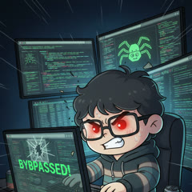

**Um raspador por tribunal**, com sessões e captchas.

2016

[figure not shown]

**Dados abertos** chegam ao Executivo, não ao Judiciário.

2020 a 2024

CNJ

**O CNJ centraliza** com DataJud, PDPJ-Br e Jus.br.

O passo zero da pesquisa empírica em Direito sempre foi **engenharia**, não estatística.

## O CNJ passou a concentrar os dados dos tribunais na PDPJ-Br

PJe eproc e-SAJ Projudi outros sistemas

Codex extrai dados dos processos eletrônicos

**PDPJ-Br**, a plataforma que integra os tribunais (Res. CNJ 335/2020), com um **data lake** central

**DataJud**

Base nacional de estatísticas (Res. 331/2020), com API pública de metadados

**Jus.br**

Portal de serviços (Res. 455/2022), com consulta unificada de processos por login

**API do data lake**

Acesso a dados consolidados para instituições (Res. 574/2024 e Portaria 316/2024)

Esquema simplificado.

## Cada caminho de acesso entrega uma parte diferente dos dados

|  | O que entrega | Quem usa | Em massa? | Custo |
| --- | --- | --- | --- | --- |
| **Site do tribunal** | processos e decisões | qualquer pessoa | não | grátis |
| **API do DataJud** | só metadados, sem partes, valor nem texto | quem aceita os termos | 120 requisições/min | grátis |
| **Jus.br** | processo e documentos públicos | usuário com login | não | grátis |
| **Data lake PDPJ** | partes e decisões, sem petições | instituições habilitadas | até 200 milhões/mês | R$ 0,0015 a 0,0019 por chamada |

O DataJud ajuda a listar casos e sortear amostras, mas a pesquisa precisa de partes, valores e texto, que estão nos caminhos mais fechados.

## O acesso completo foi desenhado para grandes instituições

Para usar a API do data lake, a Portaria CNJ 316/2024, art. 5º, exige ao mesmo tempo:

- políticas de privacidade e proteção de dados;
- infraestrutura de segurança da informação;
- auditoria capaz de reconstruir cada acesso;
- disponibilidade acima de **95%**;
- gestão de identidade para ao menos **200 mil usuários únicos por mês**.

Universidades podem ser dispensadas dos dois últimos itens, a critério da Presidência do CNJ. Pesquisadores individuais não estão cobertos.

R$ 1 mil a 35 mil por mês, em planos de uma API privada que revende dados judiciais públicos (abril de 2026)

## Enquanto isso, a comunidade liberta os dados por conta própria

Libertar dados é capturar, limpar, estruturar e publicar:

- [`juscraper`](https://github.com/jtrecenti/juscraper): raspadores abertos para mais de 25 tribunais, DataJud e Jus.br
- [`juscraper-app`](https://lab-dados.github.io/juscraper-app/): o mesmo, sem programar
- **JudeData** (USP): dados do STF em CSV documentado
- **Brasil.IO**, **Base dos Dados** e **Querido Diário**: a linhagem brasileira

Raspar resolve uma pesquisa, não a infraestrutura. Isso exige governança, fôlego e **colaboração dos tribunais**.

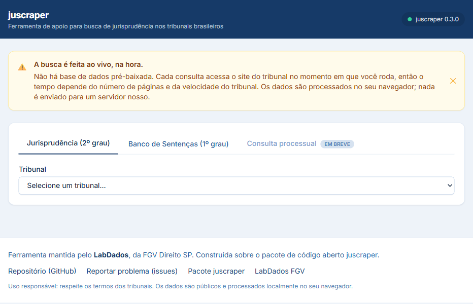

## Podemos usar esses dados em pesquisa?

## Dado público não é o mesmo que dado aberto

Dado público

Open Knowledge Foundation, Open Definition

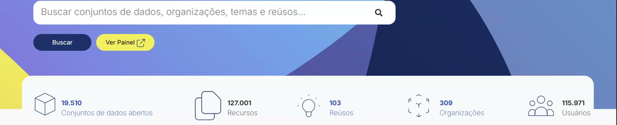

`dados.gov.br`: mais de 19 mil conjuntos. A política federal é referência, mas alcança o Executivo, não o Judiciário.

**Todo dado público deveria ser aberto?**

## O próprio CNJ trata sentenças e nomes das partes como dados públicos

> “dados públicos: dados estruturados e não estruturados relativos a número único, classe e assuntos do processo, nome das partes e de seus advogados, decisões, sentenças, votos e acórdãos […]”

Portaria CNJ 316/2024, art. 2º, I, remetendo à Res. CNJ 121/2010

Ou seja, o dado é público **e** contém informação pessoal. A pergunta não é se ele é acessível, mas **em que condições** pode ser reutilizado.

## Como os tribunais têm tratado esses dados

**STJ**: espelhos de acórdãos

[figure not shown]

ZIP, CSV e JSON, com licença CC-BY. `dadosabertos.web.stj.jus.br`

**TJDFT**: API pública de jurisprudência

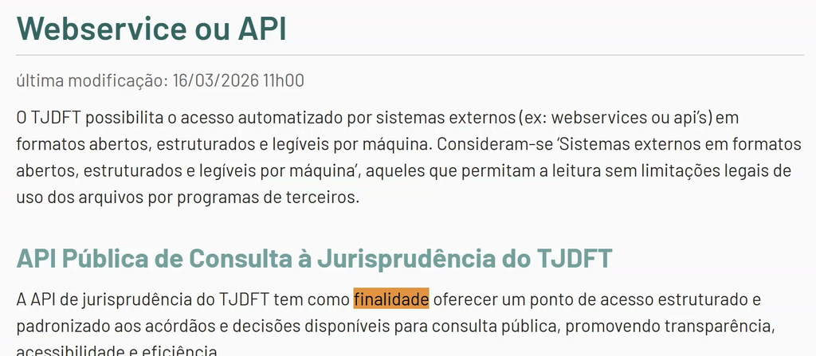

> “sem limitações legais de uso dos arquivos por programas de terceiros”

`tjdft.jus.br`, Transparência, Webservice ou API

## O TJSP tem dados públicos, mas não abertos

- A consulta é **pública**, sem cadastro.
- Não há download em massa nem licença aberta.
- Busque **“PIX”**: aparecem chaves que são CPFs.

As **empresas** de consulta processual já baixaram tudo. Quem esbarra é a **pesquisa**, que pode travar no comitê de ética.

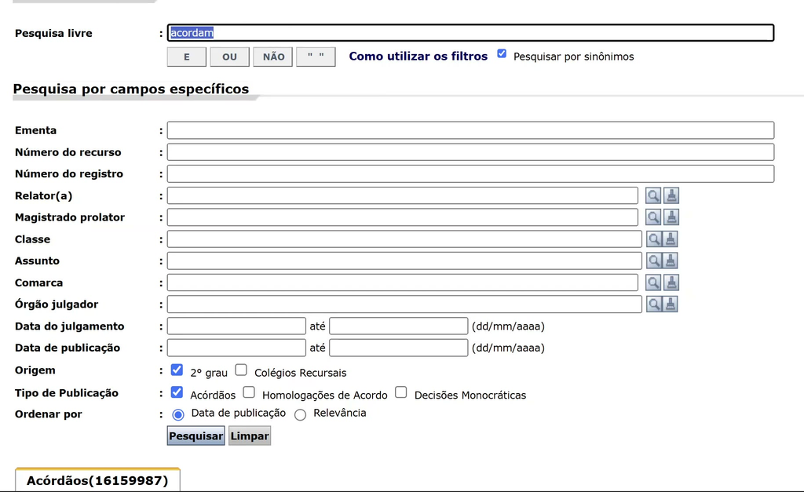

Consulta de jurisprudência do TJSP, com 16.159.987 acórdãos listados (out/2026).

## A mesma decisão pode ser aberta ou não, dependendo do tribunal

|  | STJ | TJDFT | TJSP |
| --- | --- | --- | --- |
| Decisões públicas | sim | sim | sim |
| Têm dados pessoais | sim | sim | sim |
| Acesso por máquina oficial | sim | sim | não |
| Licença aberta | CC-BY | uso sem limitação legal | não |

Primeiro caminho

São públicos, logo **deveriam ser abertos**. O TJSP só está atrasado, e a pesquisa é legítima.

Segundo caminho

Têm dados pessoais, logo **pedem comitê de ética**. Mas aí a resposta muda com o tribunal.

Mudar de tribunal não deveria mudar o que é ético pesquisar.

## Podemos abrir os dados em camadas, conforme o risco

**Aberta**

Variáveis estruturadas e metadados, sem identificar pessoas, para qualquer finalidade.

**Protegida**

Textos anonimizados, com finalidade declarada e termo de uso.

**Restrita**

Dados identificados e cruzamentos, em sala segura e com comitê de ética.

Estruturar também protege: a base publica `decisao` e `pena_anos`, e não o texto. E a mesma IA ajuda a anonimizar.

LGPD, art. 7º, §3º (finalidade, boa-fé e interesse público) e inciso IV (pesquisa). Res. CNS 510/2016, art. 1º, parágrafo único (informações de acesso público).

## O que precisamos de tribunais, comitês e universidades

CNJ Abra a PDPJ para download em massa. Iniciativas dos tribunais ajudam, mas a chave está na base central.

Comitês e reguladores Deem critérios coerentes para pesquisa com dado público, independentes do tribunal.

Pesquisa e universidades Construam juntos métodos validados e repositórios abertos, com modelos que possamos auditar.

Dado público só é público de verdade quando é aberto.

## Obrigado!

**Julio Trecenti**

`julioazt@insper.edu.br`

Slides e código abertos no repositório de slides. Redigido com apoio do Claude Code (Claude Opus 5.5). As afirmações e eventuais erros são meus.

[figure not shown]

estes slides

[figure not shown]

juscraper

[figure not shown]

juscraper-app

[figure not shown]